# Real-data disturbance–response IV — wavelet synchrony (coherence, cross-power, phase → apparent lag, amplitude)

The Morlet-wavelet approach on real MacroSheds precip→discharge — how the native signal-processing view holds up off the idealised bench (cf. analysis II), read against analysis III’s peaks

nic (nic@cascadeclimate.org)

2026-07-18

This is **analysis II’s method — Morlet wavelet coherence via WaveletComp — run on real watersheds**, the wavelet counterpart to analysis III’s peak/moments pass on the same five sites. The study is a **methods comparison**: analysis II (`syn_data/analysis_02`) established, on a clean synthetic system, what the native wavelet view sees that peaks cannot (coupling resolved jointly in time *and* frequency; a sharp sub-step lag) — and its **characteristic failure**: the *normalized, smoothed* coherence can be **fooled**, staying ≈1 even over noise, so the honest signal lives in the **un-normalized cross-power and band amplitude**. Here we test whether those strengths and that weakness reproduce on **less-deterministic real synchrony**: `climate` = daily precipitation (undisturbed driver), `log(response)` = log daily discharge, read at the **annual `P≈365 d` band**.

Four band-localized quantities, all read at `P≈365` (the seasonal band):

- **Wavelet coherence** `∈[0,1]` — normalized (smoothed) coupling strength.
- **Cross-wavelet power** — strength of *shared* oscillation at the band (un-normalized).
- **Phase difference φ** (radians) — `Angle = phase.climate − phase.response`; **climate leads ⇒ positive φ**. Shown alongside its step-unit form:
- **Apparent lag** = `φ · P / (2π)` days — φ rescaled to “how many days behind.” It is **gated to NA where the driver has no annual-band amplitude** (φ undefined there); a surviving value near `±½ yr` means *antiphase*, not a real six-month delay (see “Where the shared power lives”).
- **Amplitude ratio** — band amplitude `response / climate` (rescaled back to physical units; see the `×sd` note in `band_trace`).

**Provenance & framing.** Discharge is fully observed; **precip is partly modelled infill** (negligible at hbef/fernow, ~13% at hjandrews). **`santa_barbara_MC06` is dropped** — its precip driver was ~88% modelled infill (a wavelet there reads a modelled driver, not observed rain); it stays in the EDA, where its coverage is now shown. And a long-term trend sits *above* the analyzed range (upper period `730 d`), so `loess.span = 0` (no detrending) is retained without trend-contaminating the seasonal read. Real precip is episodic, not a clean sine, so — as analysis III already hinted — expect coherence to saturate and the *power* channels to carry whatever real story there is.

## Helpers

```r
# All wavelet helpers now live in R/wavelet_kernel.R (sourced in setup) — edit once, not three
# times. Build THIS notebook's copies from a small config and inject them into the chunk
# environment, so every call site below stays bare (wco(df), band_trace(wc, df), plot_wc(...), ...).
# Config = the real P→Q leg: annual band (P = 365 d, daily so step = 1), an episodic precip driver
# whose annual amplitude is often ~noise ⇒ PHASE GATING on (blank φ/lag where the driver has no band
# signal; report settled φ/lag only where block phases concentrate, R ≥ 0.5); real pre/dist/post
# phases (no `transition`); calendar-quarter shading; the lag facet breaks at the ±π wrap and shows
# the antiphase rails. See tickets/wavelet_significance_mask.plan.md and R/wavelet_kernel.R.
list2env(make_wavelet_kernel(list(
  P_days         = P,                          # 365 — annual band in days (daily data ⇒ step = 1)
  phase_gate     = TRUE,                         # precip barely oscillates at P ⇒ gate φ/lag to NA there
  PHASE_MIN_AMP  = PHASE_MIN_AMP,                # 0.5 — trace gate on driver band amplitude
  PHASE_MIN_R    = PHASE_MIN_R,                  # 0.5 — settled gate on block-phase concentration
  has_transition = FALSE,                        # real phases are pre / disturbance / post
  season         = TRUE,                         # alternating calendar-quarter shading
  trace_x        = "time",
  lag_wrap_break = TRUE,                          # break the lag line at ±π; draw the ±½-yr antiphase rails
  lag_lab        = "app. lag (d)",
  smooth_w       = 61,                            # resid-derivative smoothing window (days)
  lowerPeriod    = 4, upperPeriod = 730,          # ~a week → two years (week/month/year guides in view)
  wc_marks       = c("1 wk" = 7, "1 mo" = 30, "3 mo" = 91, "1 yr" = 365),
  dist_vline     = "grey70",
  include_phase_R = TRUE,                          # settled table carries the phase_R column
  gain_fmt       = "%.3f",
  timelab        = "time (days)", periodlab = "period (days)",
  x_lab          = "time (days)",                  # trace/resid x-axis label (04 uses "time (days)")
  resid_sub      = function(g, L, step)
    sprintf("pre-fit predictor:  log(response)(t) ≈ %.3f · climate(t − %d)", g, L),
  table_note     = "· phase_R = phase concentration among the phase-defined steps (φ/lag → NA if it ever drops < 0.5). A high phase_R is NOT proof of a real annual coupling — read **xpower**: where it is small (chemistry sites, e.g. hbef ≈ 0.03) a large lag is a phase angle at a band the driver barely occupies, not a genuine delay; a strong annual coupling (hjandrews, xpower ≈ 0.4) shows both."
)), environment())
```

```
## <environment: R_GlobalEnv>
```

```r
# Annual-harmonic R² (04-only diagnostic; cheap OLS on cos/sin at 365 d): how much of each channel's
# variance is a clean annual cycle. Precip ≈ 0 (aseasonal driver) is the numeric root of the phase
# degeneracy. Kept notebook-local — it is a one-off, not a shared wavelet helper.
annual_r2 <- function(d) {
  w <- 2 * pi / P; C <- cos(w * d$time); S <- sin(w * d$time)
  r2 <- function(y) summary(lm(y ~ C + S))$r.squared
  tibble(site = d$site[1], precip_annual_r2 = r2(d$climate), logQ_annual_r2 = r2(d$log_response))
}
```

```r
# response (discharge) analyzed in log space → add log_response once at load (prep floored zeros).
sites <- c("hbef_w1", "hjandrews_GSWS10", "fernow_WS-3", "fernow_WS-5")   # MC06 dropped (88% modelled precip driver)
D <- lapply(sites, function(s)
  read_csv(sprintf("%s__series_daily.csv", s), show_col_types = FALSE) %>%
    mutate(phase = factor(phase, c("pre", "disturbance", "post")),
           log_response = log(response)))
names(D) <- sites
# plot labels come from the tracked CSVs themselves (site/disturbance/date carried by the prep) —
# no dependency on any external file, so 04 builds from the committed *__series_daily.csv alone.
# Format: "<site> <disturbance-year> <disturbance>", e.g. "fernow_WS-5 2007 timber_harvest".
label <- setNames(vapply(D, function(d)
  sprintf("%s %s %s", d$site[1],
          format(min(d$date[d$phase == "disturbance"]), "%Y"), d$disturbance[1]),
  character(1)), sites)
```

```r
# One coherency transform per site → reused by every image, trace and table below (~1 min total).
WC <- lapply(D, wco)
TR <- Map(band_trace, WC, D)
SM <- lapply(TR, wave_summary)
```

## Data provenance (`ms_interp`)

```r
prov <- bind_rows(lapply(D, function(d) tibble(
  site = d$site[1],
  climate_interp_pct  = round(100 * mean(d$climate_interp), 1),
  response_interp_pct = round(100 * mean(d$response_interp), 1))))
cat(kable(prov, caption = "Percent of each channel that is MacroSheds gap-fill (modelled), per site (the four analyzed; MC06 dropped for its ~88% modelled precip driver — see intro)."), sep = "\n")
```

Percent of each channel that is MacroSheds gap-fill (modelled), per site (the four analyzed; MC06 dropped for its ~88% modelled precip driver — see intro).

| site | climate_interp_pct | response_interp_pct |
| --- | --- | --- |
| hbef_w1 | 0.0 | 0 |
| hjandrews_GSWS10 | 13.4 | 0 |
| fernow_WS-3 | 0.0 | 0 |
| fernow_WS-5 | 0.0 | 0 |

# Where the shared power lives (and why the annual-band lag is degenerate at some sites)

Before the per-site reads, one diagnostic that reframes everything below. At some sites the apparent-lag panel at `P≈365` behaves badly — pinning to `±½ yr` and flipping — for a concrete reason: **where the driver barely oscillates at the annual band**, its phase is near undefined, so the phase *difference* wanders across `±π`, which the raw `φ→lag` map renders as a `±½ yr` sawtooth (a circular quantity on a linear axis, not a six-month delay). Un-normalized cross-power vs period shows *where the shared oscillation actually is* — and, crucially, it **differs by site**.

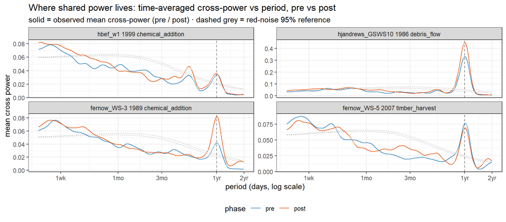

Figure 1. Time-averaged cross-wavelet power vs period (log x), per site, split PRE vs POST (solid blue / orange), each averaged over that phase’s settled EF-buffered window — the same windows the pre/post tables use, so this is the spectral view of the settled comparison, free of COI/disturbance bleed. Dashed grey = the red-noise 95% reference (analytic AR(1), DOF-inflated per window; Torrence & Compo 1998 — tight at event periods, mildly conservative at the annual band). Power ABOVE it is shared oscillation beyond independent red noise; a pre→post gap at a period is where the disturbance moved shared power there. The annual band (grey dashed vertical, 365 d) carries a genuine shared-power peak at hjandrews (dominant) and fernow, but at hbef the shared power is broadband and event-heavy with only a weak annual bump — the degenerate case un-normalized cross-power separates from a real annual coupling, a distinction the saturated coherence (≈1 everywhere) cannot make.

```r
# Split PRE vs POST (EF-buffered settled windows — the same wave_summary uses); kernel returns
# `id`, `phase`, `period`, `power`, `ref`.
xps <- bind_rows(Map(function(wc, df, id) xpower_spectrum(wc, df, id, split = TRUE), WC, D, names(WC))) %>%
  mutate(id = factor(id, sites))
ggplot(xps, aes(period, power, colour = phase)) +
  geom_vline(xintercept = P, linetype = 2, colour = "grey45") +
  geom_line(aes(period, ref, group = phase), colour = "grey55", linetype = 2, linewidth = 0.3) +  # red-noise 95%, per phase
  geom_line(linewidth = 0.5) +
  facet_wrap(~ id, scales = "free_y", labeller = as_labeller(label)) +   # strip = site + disturbance (matches section headers)
  scale_colour_manual(values = c(pre = "#3182bd", post = "#e6550d")) +
  scale_x_log10(breaks = c(7, 30, 91, 365, 730), labels = c("1wk", "1mo", "3mo", "1yr", "2yr")) +
  labs(title = "Where shared power lives: time-averaged cross-power vs period, pre vs post",
       subtitle = "solid = observed mean cross-power (pre / post) · dashed grey = red-noise 95% reference",
       colour = "phase", x = "period (days, log scale)", y = "mean cross power")
```

```r
r2tab <- bind_rows(lapply(D, annual_r2))
cat(kable(r2tab, digits = 3,
          caption = "Annual-harmonic R² (OLS on cos/sin at 365 d). Precip's annual cycle is near-zero at hbef/fernow (an aseasonal driver — hence the undefined band phase and ±½ yr wrap there) and only modest (~0.09) at hjandrews; log(discharge) carries the real annual cycle at every site (temperature/snow/ET-driven, not a seasonal precip cycle)."), sep = "\n")
```

Annual-harmonic R² (OLS on cos/sin at 365 d). Precip’s annual cycle is near-zero at hbef/fernow (an aseasonal driver — hence the undefined band phase and ±½ yr wrap there) and only modest (~0.09) at hjandrews; log(discharge) carries the real annual cycle at every site (temperature/snow/ET-driven, not a seasonal precip cycle).

| site | precip_annual_r2 | logQ_annual_r2 |
| --- | --- | --- |
| hbef_w1 | 0.001 | 0.221 |
| hjandrews_GSWS10 | 0.087 | 0.607 |
| fernow_WS-3 | 0.002 | 0.389 |
| fernow_WS-5 | 0.003 | 0.384 |

So the annual-band lag is trustworthy only where the driver actually oscillates there. At **hbef** the near-1 coherence coexists with a wrapping, mostly-gated phase — the signature of reading a nearly-aseasonal driver at a band it does not occupy; its real shared power is broadband. At **hjandrews** the annual cross-power peak is dominant and the lag sits cleanly at ~`+35 d` (below), a genuine coupling. In the per-site traces the lag panel is therefore **blanked** wherever the driver has too little annual-band amplitude to define a phase, and any surviving value is drawn against `0 / ±½ yr` guides so a rail-hugging cluster reads as *antiphase*, not a six-month delay.

# hbef_w1 — chemical addition (pulse)

Chemistry manipulation, not water yield — the seasonal precip→discharge coupling should be a near-null across the disturbance. A good reference for what the wavelet returns when nothing hydrologic happened.

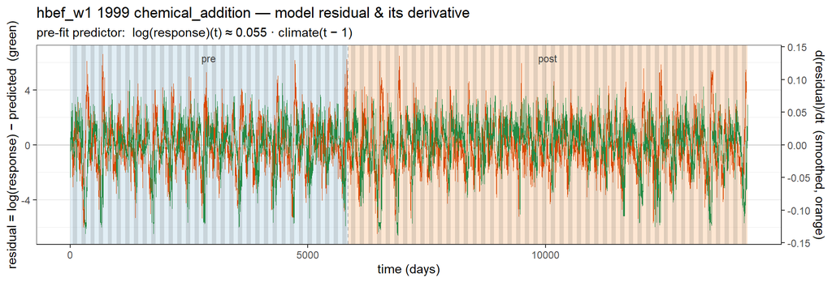

Figure 2. hbef_w1 — model residual (green) + smoothed derivative (orange, right axis); phases shaded, dashed = disturbance.

```r
plot_resid(D[["hbef_w1"]], paste(label["hbef_w1"], "— model residual & its derivative"))
```

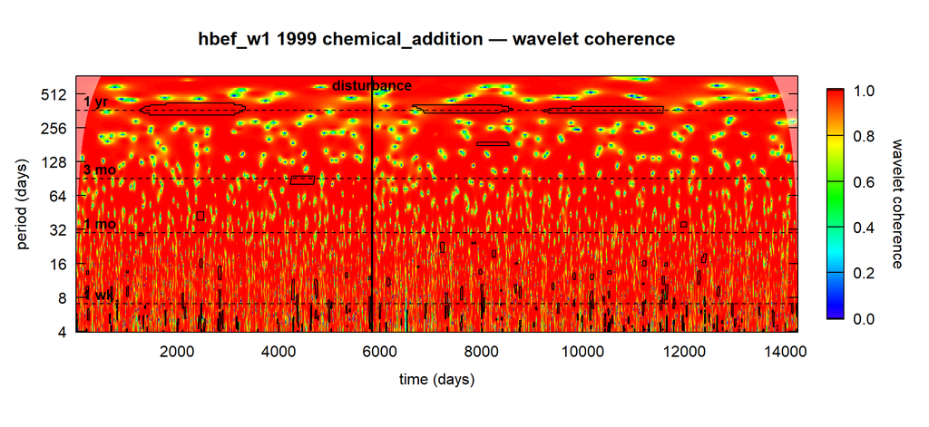

```r
plot_wc(WC[["hbef_w1"]], D[["hbef_w1"]], paste(label["hbef_w1"], "— wavelet coherence"))
```

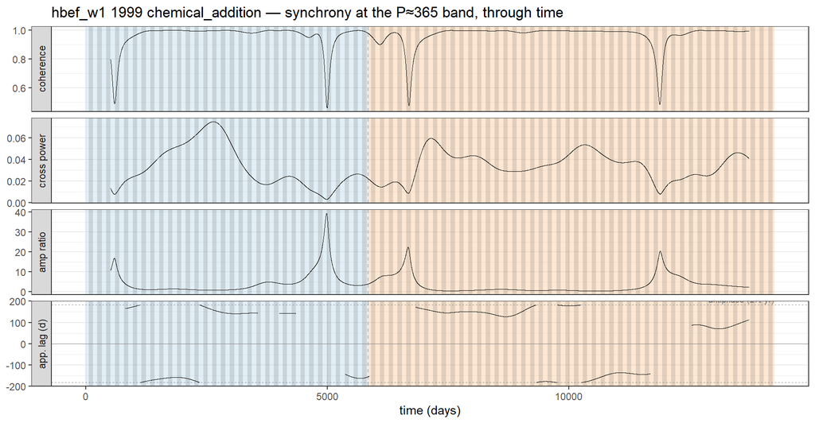

Figure 4. hbef_w1 — band (P≈365) metrics through time; COI edges blanked, phases shaded.

```r
plot_band_trace(TR[["hbef_w1"]], paste(label["hbef_w1"], "— synchrony at the P≈365 band, through time"))
```

```r
emit_table(SM[["hbef_w1"]], "hbef_w1 — band synchrony, settled pre vs post (n_blocks = annual cycles the SEs rest on)")
```

hbef_w1 — band synchrony, settled pre vs post (n_blocks = annual cycles the SEs rest on) · phase_R = phase concentration among the phase-defined steps (φ/lag → NA if it ever drops < 0.5). A high phase_R is NOT proof of a real annual coupling — read **xpower**: where it is small (chemistry sites, e.g. hbef ≈ 0.03) a large lag is a phase angle at a band the driver barely occupies, not a genuine delay; a strong annual coupling (hjandrews, xpower ≈ 0.4) shows both.

| phase | n_blocks | coherence | xpower | amp_ratio | phi | lag | phase_R |
| --- | --- | --- | --- | --- | --- | --- | --- |
| pre | 14 | 0.96 | 0.03 | 4.94 | 2.86 | 166.20 | 0.92 |
| post | 21 | 0.97 | 0.04 | 3.17 | 2.65 | 154.08 | 0.71 |

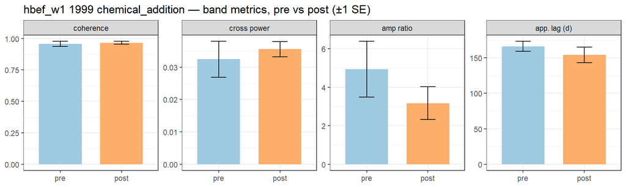

Figure 5. hbef_w1 — pre vs post band metrics, ±1 SE (block SE).

```r
plot_wave_bars(SM[["hbef_w1"]], paste(label["hbef_w1"], "— band metrics, pre vs post (±1 SE)"))
```

# hjandrews_GSWS10 — debris flow (pulse)

A physical channel disturbance that could alter the storm→flow routing. Watch the band amplitude ratio and apparent lag across 1986. *(~13% of precip is modelled infill.)*

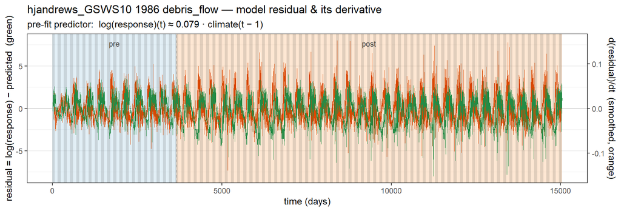

Figure 6. hjandrews_GSWS10 — model residual (green) + derivative (orange); phases shaded, dashed = disturbance.

```r
plot_resid(D[["hjandrews_GSWS10"]], paste(label["hjandrews_GSWS10"], "— model residual & its derivative"))
```

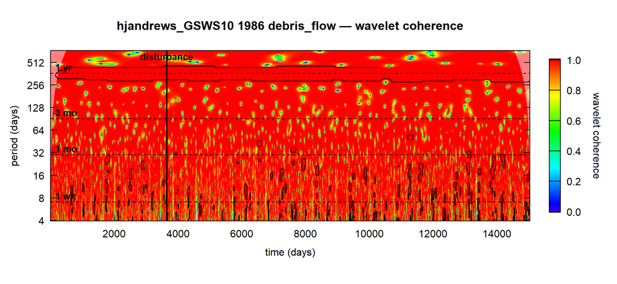

Figure 7. hjandrews_GSWS10 — wavelet coherence spectrum.

```r
plot_wc(WC[["hjandrews_GSWS10"]], D[["hjandrews_GSWS10"]], paste(label["hjandrews_GSWS10"], "— wavelet coherence"))
```

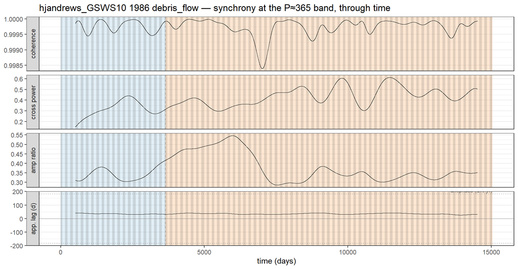

Figure 8. hjandrews_GSWS10 — band metrics through time.

```r
plot_band_trace(TR[["hjandrews_GSWS10"]], paste(label["hjandrews_GSWS10"], "— synchrony at the P≈365 band, through time"))
```

```r
emit_table(SM[["hjandrews_GSWS10"]], "hjandrews_GSWS10 — band synchrony, settled pre vs post")
```

hjandrews_GSWS10 — band synchrony, settled pre vs post · phase_R = phase concentration among the phase-defined steps (φ/lag → NA if it ever drops < 0.5). A high phase_R is NOT proof of a real annual coupling — read **xpower**: where it is small (chemistry sites, e.g. hbef ≈ 0.03) a large lag is a phase angle at a band the driver barely occupies, not a genuine delay; a strong annual coupling (hjandrews, xpower ≈ 0.4) shows both.

| phase | n_blocks | coherence | xpower | amp_ratio | phi | lag | phase_R |
| --- | --- | --- | --- | --- | --- | --- | --- |
| pre | 8 | 1 | 0.32 | 0.34 | 0.61 | 35.46 | 1 |
| post | 29 | 1 | 0.44 | 0.37 | 0.61 | 35.33 | 1 |

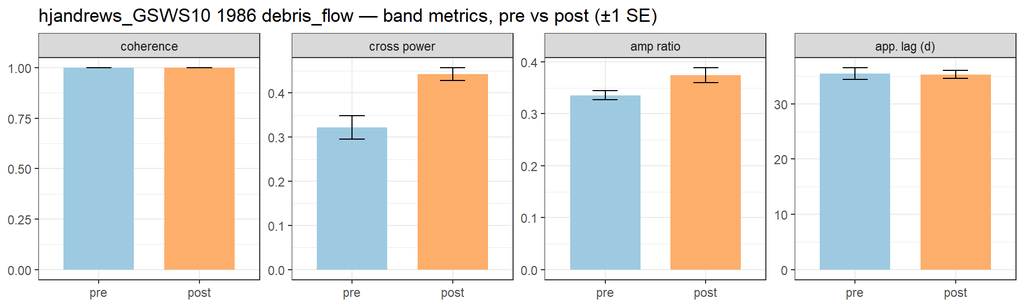

Figure 9. hjandrews_GSWS10 — pre vs post band metrics, ±1 SE.

```r
plot_wave_bars(SM[["hjandrews_GSWS10"]], paste(label["hjandrews_GSWS10"], "— band metrics, pre vs post (±1 SE)"))
```

# fernow_WS-3 — chemical addition (chronic)

Chronic acidification, open-ended — “post” is a persistently manipulated regime. Chemistry target, so like hbef expect little hydrologic signature, but the long record gives the wavelet many annual cycles to average.

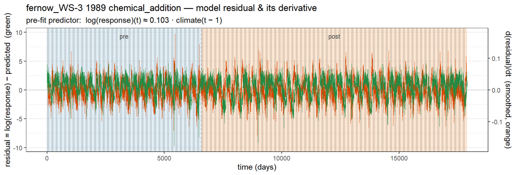

Figure 10. fernow_WS-3 — model residual (green) + derivative (orange); phases shaded, dashed = disturbance.

```r
plot_resid(D[["fernow_WS-3"]], paste(label["fernow_WS-3"], "— model residual & its derivative"))
```

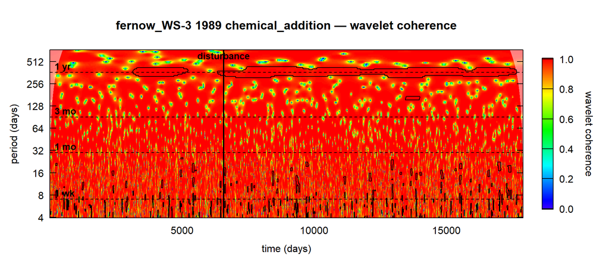

Figure 11. fernow_WS-3 — wavelet coherence spectrum.

```r
plot_wc(WC[["fernow_WS-3"]], D[["fernow_WS-3"]], paste(label["fernow_WS-3"], "— wavelet coherence"))
```

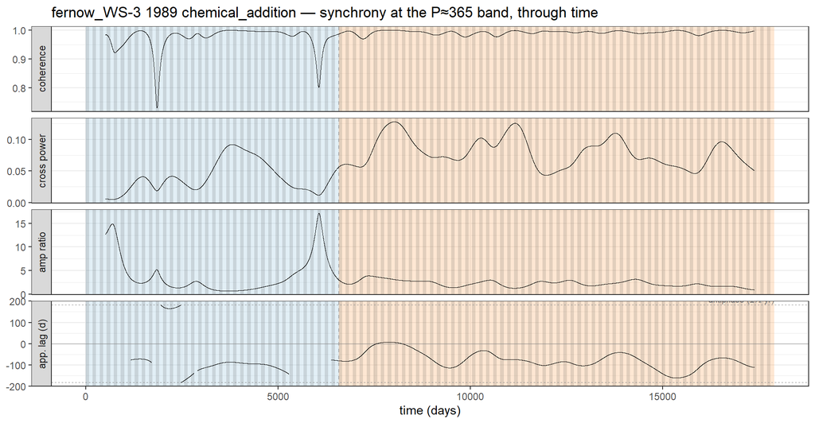

Figure 12. fernow_WS-3 — band metrics through time.

```r
plot_band_trace(TR[["fernow_WS-3"]], paste(label["fernow_WS-3"], "— synchrony at the P≈365 band, through time"))
```

```r
emit_table(SM[["fernow_WS-3"]], "fernow_WS-3 — band synchrony, settled pre vs post")
```

fernow_WS-3 — band synchrony, settled pre vs post · phase_R = phase concentration among the phase-defined steps (φ/lag → NA if it ever drops < 0.5). A high phase_R is NOT proof of a real annual coupling — read **xpower**: where it is small (chemistry sites, e.g. hbef ≈ 0.03) a large lag is a phase angle at a band the driver barely occupies, not a genuine delay; a strong annual coupling (hjandrews, xpower ≈ 0.4) shows both.

| phase | n_blocks | coherence | xpower | amp_ratio | phi | lag | phase_R |
| --- | --- | --- | --- | --- | --- | --- | --- |
| pre | 16 | 0.97 | 0.04 | 4.24 | -1.92 | -111.33 | 0.82 |
| post | 29 | 0.99 | 0.08 | 2.25 | -1.33 | -77.03 | 0.80 |

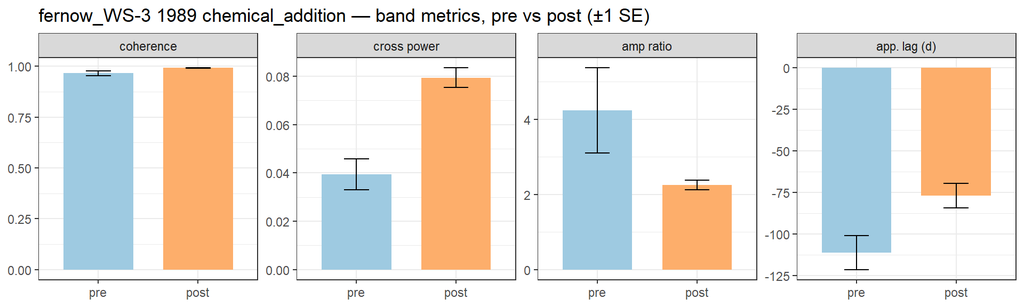

Figure 13. fernow_WS-3 — pre vs post band metrics, ±1 SE.

```r
plot_wave_bars(SM[["fernow_WS-3"]], paste(label["fernow_WS-3"], "— band metrics, pre vs post (±1 SE)"))
```

# fernow_WS-5 — timber harvest (pulse)

The clearest water-yield disturbance (2007 clearcut): reduced transpiration raises discharge and can sharpen the storm response — the site where the seasonal-band amplitude ratio has the most reason to move.

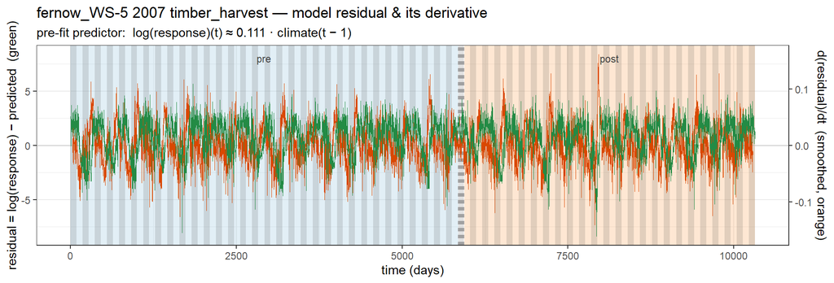

Figure 14. fernow_WS-5 — model residual (green) + derivative (orange); phases shaded, dashed = disturbance.

```r
plot_resid(D[["fernow_WS-5"]], paste(label["fernow_WS-5"], "— model residual & its derivative"))
```

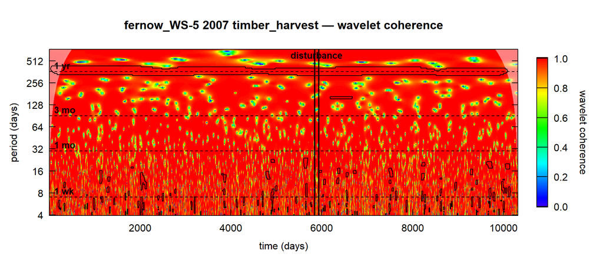

Figure 15. fernow_WS-5 — wavelet coherence spectrum.

```r
plot_wc(WC[["fernow_WS-5"]], D[["fernow_WS-5"]], paste(label["fernow_WS-5"], "— wavelet coherence"))
```

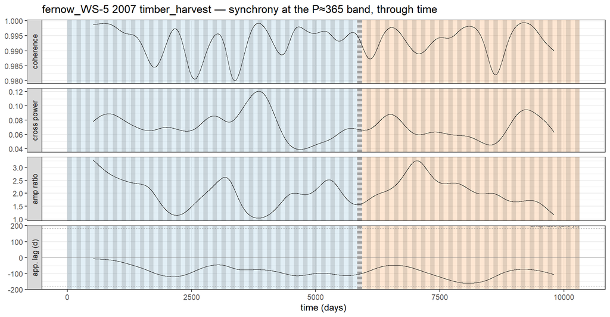

Figure 16. fernow_WS-5 — band metrics through time.

```r
plot_band_trace(TR[["fernow_WS-5"]], paste(label["fernow_WS-5"], "— synchrony at the P≈365 band, through time"))
```

```r
emit_table(SM[["fernow_WS-5"]], "fernow_WS-5 — band synchrony, settled pre vs post")
```

fernow_WS-5 — band synchrony, settled pre vs post · phase_R = phase concentration among the phase-defined steps (φ/lag → NA if it ever drops < 0.5). A high phase_R is NOT proof of a real annual coupling — read **xpower**: where it is small (chemistry sites, e.g. hbef ≈ 0.03) a large lag is a phase angle at a band the driver barely occupies, not a genuine delay; a strong annual coupling (hjandrews, xpower ≈ 0.4) shows both.

| phase | n_blocks | coherence | xpower | amp_ratio | phi | lag | phase_R |
| --- | --- | --- | --- | --- | --- | --- | --- |
| pre | 14 | 0.99 | 0.07 | 2.0 | -1.35 | -78.18 | 0.87 |
| post | 10 | 0.99 | 0.07 | 2.1 | -1.76 | -101.96 | 0.84 |

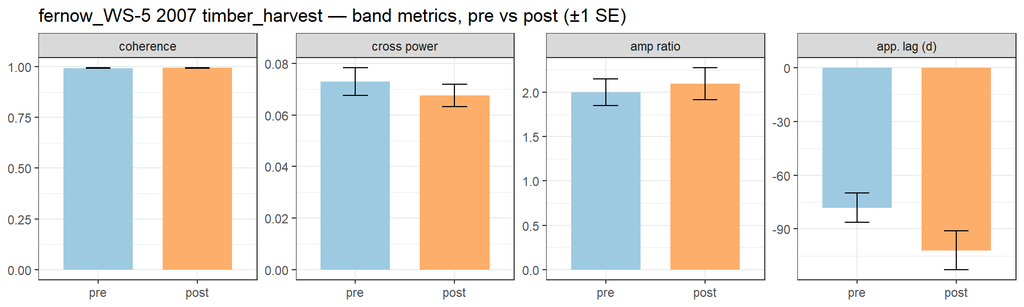

Figure 17. fernow_WS-5 — pre vs post band metrics, ±1 SE.

```r
plot_wave_bars(SM[["fernow_WS-5"]], paste(label["fernow_WS-5"], "— band metrics, pre vs post (±1 SE)"))
```

# Cross-site summary

Post-minus-pre change in the four band metrics per site, each Δ carrying its propagated SE (`√(se_pre² + se_post²)`). In analysis II the synthetic scenarios separated cleanly and taught the lesson that *coherence alone is not enough*; here the question is which of these real sites, if any, moves a **power/amplitude** channel beyond its (now well-resolved) error.

```r
sm_all <- bind_rows(SM, .id = "site")
delta <- metrics_long(sm_all, c("site", "phase")) %>%
  pivot_wider(names_from = phase, values_from = c(value, se)) %>%
  mutate(delta    = value_post - value_pre,
         delta_se = sqrt(se_pre^2 + se_post^2),
         site     = factor(site, sites))
```

```r
cat(kable(delta %>% transmute(site, metric = metric_labs[as.character(metric)],
                              pre = value_pre, post = value_post, delta, delta_se),
          digits = 2, caption = "pre → post change in band metrics, all sites (delta_se = propagated ±1 SE)"), sep = "\n")
```

pre → post change in band metrics, all sites (delta_se = propagated ±1 SE)

| site | metric | pre | post | delta | delta_se |
| --- | --- | --- | --- | --- | --- |
| hbef_w1 | coherence | 0.96 | 0.97 | 0.01 | 0.02 |
| hbef_w1 | cross power | 0.03 | 0.04 | 0.00 | 0.01 |
| hbef_w1 | amp ratio | 4.94 | 3.17 | -1.77 | 1.68 |
| hbef_w1 | app. lag (d) | 166.20 | 154.08 | -12.12 | 13.21 |
| hjandrews_GSWS10 | coherence | 1.00 | 1.00 | 0.00 | 0.00 |
| hjandrews_GSWS10 | cross power | 0.32 | 0.44 | 0.12 | 0.03 |
| hjandrews_GSWS10 | amp ratio | 0.34 | 0.37 | 0.04 | 0.02 |
| hjandrews_GSWS10 | app. lag (d) | 35.46 | 35.33 | -0.13 | 1.29 |
| fernow_WS-3 | coherence | 0.97 | 0.99 | 0.03 | 0.01 |
| fernow_WS-3 | cross power | 0.04 | 0.08 | 0.04 | 0.01 |
| fernow_WS-3 | amp ratio | 4.24 | 2.25 | -1.98 | 1.14 |
| fernow_WS-3 | app. lag (d) | -111.33 | -77.03 | 34.30 | 12.56 |
| fernow_WS-5 | coherence | 0.99 | 0.99 | 0.00 | 0.00 |
| fernow_WS-5 | cross power | 0.07 | 0.07 | -0.01 | 0.01 |
| fernow_WS-5 | amp ratio | 2.00 | 2.10 | 0.10 | 0.23 |
| fernow_WS-5 | app. lag (d) | -78.18 | -101.96 | -23.78 | 13.56 |

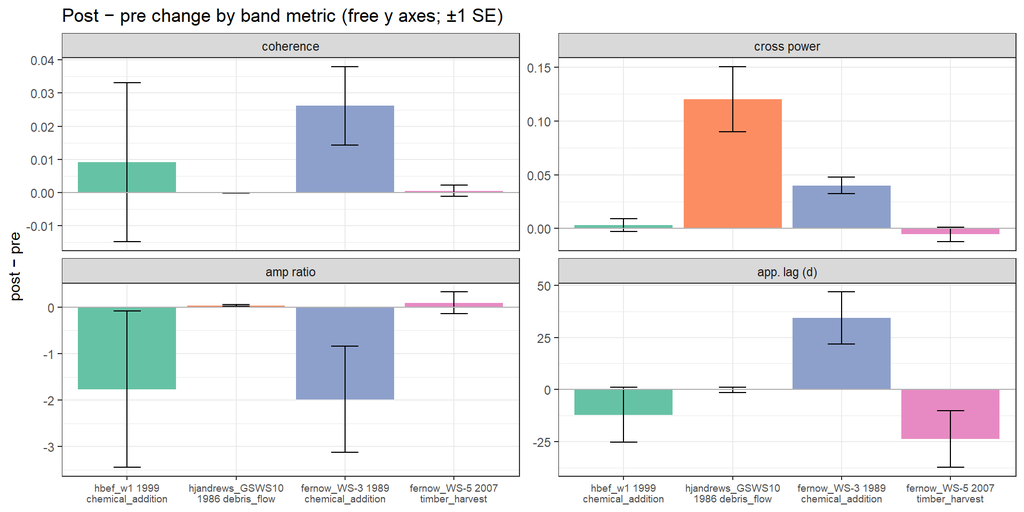

Figure 18. Post − pre change per site, faceted by band metric (free y), ±1 propagated SE. The lesson from analysis II carries over: coherence barely moves anywhere (it saturates on real data too), so if anything registers it is in cross-power / amplitude.

```r
# x-axis labels = site + disturbance (the `label` vector), wrapped to fit; matches the section headers.
sitelab <- function(s) vapply(s, function(x) paste(strwrap(label[[x]], 17), collapse = "\n"), character(1))
ggplot(delta, aes(site, delta, fill = site)) +
  geom_col() +
  geom_errorbar(aes(ymin = delta - delta_se, ymax = delta + delta_se), width = 0.25, colour = "black", na.rm = TRUE) +
  geom_hline(yintercept = 0, colour = "grey70") +
  facet_wrap(~ metric, scales = "free_y", labeller = as_labeller(metric_labs)) +
  scale_fill_brewer(palette = "Set2", guide = "none") +
  scale_x_discrete(labels = sitelab) +
  labs(title = "Post − pre change by band metric (free y axes; ±1 SE)", x = NULL, y = "post − pre") +
  theme(axis.text.x = element_text(size = 7))
```

**Takeaways — the native wavelet view on real synchrony, next to analysis III.** The lesson analysis II taught on synthetic data reappears **unprompted** on real watersheds: WaveletComp’s *normalized, smoothed* coherence **saturates near 1 across the whole record at every site** (see the red spectra), so — exactly as in the synthetic Desync case — coherence is not a usable discriminator here; whatever real change exists must be read from **un-normalized cross-power and band amplitude**, which the wavelet still resolves with well-populated error bars (decades of cycles, unlike the synthetic ~2). The tell is site-dependent: where near-1 coherence coexists with a **wrapping, mostly-gated** annual-band phase (hbef — precip’s annual R² ≈ 0), that pairing is the *signature* of the smoothing artifact, and the real shared power is broadband. Un-normalized cross-power, by contrast, **separates** that degenerate case from a genuine annual coupling (hjandrews’ dominant annual peak and clean ~35 d lag) — the discrimination the saturated coherence cannot provide (first figure). Against analysis III: the peak/moments lens frayed on the episodic precip driver (an unstable “period”), while the wavelet keeps a clean, time-resolved amplitude/lag read but hands back a **falsely reassuring coherence** — two methods, two different partial views, each incomplete in its own way. That, not any single site’s number, is the point of running both: the choice of synchrony metric decides what you can and cannot see, and on real, less-deterministic coupling neither view is sufficient alone. ```